# Module 9: Code-along - Palmer Penguins

George Kachergis, Jessica Kosie[^1]

Derek Powell[^2]

03 November, 2026

# Penguins!

```r
library(tidyverse)
library(palmerpenguins)
library(scatterPlotMatrix)
data("penguins")

#If you would like to turn off scientific notation, run this code
options(scipen = 999)
```

```r
# some helper functions - run this code to create functions (we'll do more with them later)

plot_residual_hist <- function(fit){
  tibble(residual = fit$residuals) %>%
    ggplot(aes(x=residual)) +
    geom_histogram()
}

plot_qq <- function(fit){
  tibble(residual = fit$residuals) %>%
    ggplot(aes(sample = residual)) + # NOTE: stat_qq* expects a sample aesthetic
    stat_qq() +
    stat_qq_line() +
    labs(x="Theoretical quantile", y = "Observed quantile")
}

plot_residual_predicted <- function(fit){
  tibble(
    predicted = fit$fitted.values,
    residual = fit$residuals
  ) %>%
    ggplot(aes(x = predicted, y = residual)) +
    geom_point() +
    geom_hline(yintercept = 0)
}
```

## Meet the penguins!

Learn about the dataset at: https://allisonhorst.github.io/palmerpenguins/

Use `glimpse()` to check out the `penguins` dataset.

```r
glimpse(penguins)
```

```
## Rows: 344
## Columns: 8
## $ species           <fct> Adelie, Adelie, Adelie, Adelie, Adelie, Adelie, Adel…
## $ island            <fct> Torgersen, Torgersen, Torgersen, Torgersen, Torgerse…
## $ bill_length_mm    <dbl> 39.1, 39.5, 40.3, NA, 36.7, 39.3, 38.9, 39.2, 34.1, …
## $ bill_depth_mm     <dbl> 18.7, 17.4, 18.0, NA, 19.3, 20.6, 17.8, 19.6, 18.1, …
## $ flipper_length_mm <int> 181, 186, 195, NA, 193, 190, 181, 195, 193, 190, 186…
## $ body_mass_g       <int> 3750, 3800, 3250, NA, 3450, 3650, 3625, 4675, 3475, …
## $ sex               <fct> male, female, female, NA, female, male, female, male…
## $ year              <int> 2007, 2007, 2007, 2007, 2007, 2007, 2007, 2007, 2007…
```

```r
unique(penguins$species)
```

```
## [1] Adelie    Gentoo    Chinstrap
## Levels: Adelie Chinstrap Gentoo
```

## Let’s predict something!

Let’s break the rules and jump right into making a model. We’ll make a model of bill lengths from penguin size—do bigger penguins have bigger bills?.

The model formula will be `bill_length_mm ~ body_mass_g`.

How would you interpret the intercept of this model? How would you interpret the coefficient for body mass?

```r
mod <- lm(bill_length_mm ~ body_mass_g, data=penguins)
summary(mod)
```

```
##
## Call:
## lm(formula = bill_length_mm ~ body_mass_g, data = penguins)
##
## Residuals:
##      Min       1Q   Median       3Q      Max
## -10.1251  -3.0434  -0.8089   2.0711  16.1109
##
## Coefficients:
##               Estimate Std. Error t value            Pr(>|t|)
## (Intercept) 26.8988724  1.2691478   21.19 <0.0000000000000002 ***
## body_mass_g  0.0040514  0.0002967   13.65 <0.0000000000000002 ***
## ---
## Signif. codes:  0 '***' 0.001 '**' 0.01 '*' 0.05 '.' 0.1 ' ' 1
##
## Residual standard error: 4.394 on 340 degrees of freedom
##   (2 observations deleted due to missingness)
## Multiple R-squared:  0.3542, Adjusted R-squared:  0.3523
## F-statistic: 186.4 on 1 and 340 DF,  p-value: < 0.00000000000000022
```

### Transform a variable

Let’s transform the variable to make our coefficient better for interpretation. Then fit the model again.

Take a minute to look at the code below. What are we doing in this code?

How would you interpret the intercept of this model? How would you interpret the coefficient for body mass?

```r
penguins_sc <- penguins %>%
  filter(!is.na(sex), !is.na(bill_length_mm))  %>%
  mutate(body_mass_kg = body_mass_g / 1000,
         body_mass_kg_c = scale(body_mass_kg, center=TRUE, scale=FALSE),
         bill_length_cm = bill_length_mm / 10,
         flipper_length_cm = flipper_length_mm / 10,
         bill_depth_cm = bill_depth_mm / 10) %>%
  select(-body_mass_g, -bill_length_mm, -bill_depth_mm, -flipper_length_mm)

mod <- lm(bill_length_cm ~ body_mass_kg_c, data=penguins_sc)
summary(mod)
```

```
##
## Call:
## lm(formula = bill_length_cm ~ body_mass_kg_c, data = penguins_sc)
##
## Residuals:
##      Min       1Q   Median       3Q      Max
## -1.01652 -0.30664 -0.07672  0.22356  1.60371
##
## Coefficients:
##                Estimate Std. Error t value            Pr(>|t|)
## (Intercept)     4.39928    0.02424  181.45 <0.0000000000000002 ***
## body_mass_kg_c  0.40033    0.03016   13.28 <0.0000000000000002 ***
## ---
## Signif. codes:  0 '***' 0.001 '**' 0.01 '*' 0.05 '.' 0.1 ' ' 1
##
## Residual standard error: 0.4424 on 331 degrees of freedom
## Multiple R-squared:  0.3475, Adjusted R-squared:  0.3455
## F-statistic: 176.2 on 1 and 331 DF,  p-value: < 0.00000000000000022
```

And inspect our model’s fit via the residuals. Here’s where we using the functions we created earlier!

Take a look at the code we used above to create the functions. What argument(s) do we need to give them?

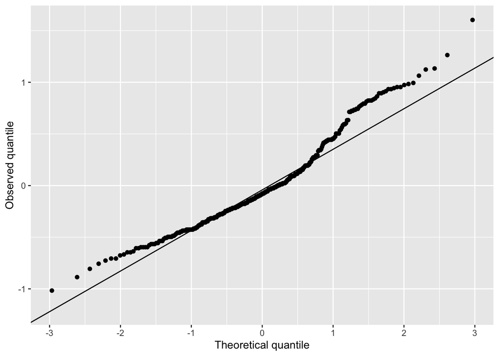

```r
plot_qq(mod)
```

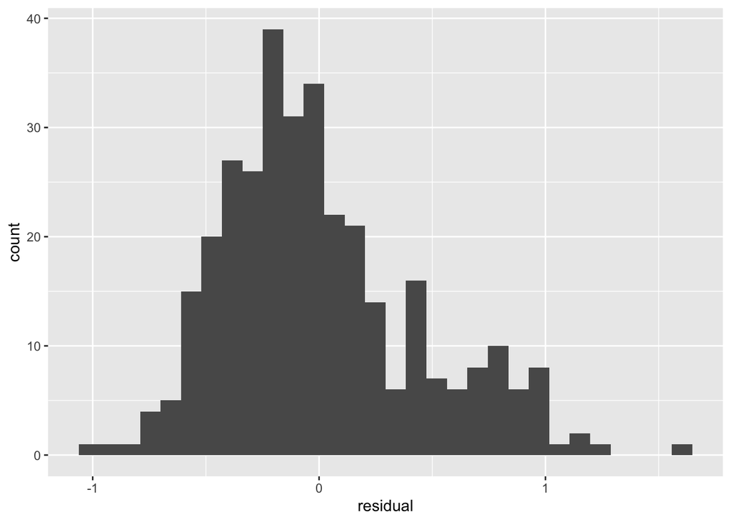

```r
plot_residual_hist(mod)
```

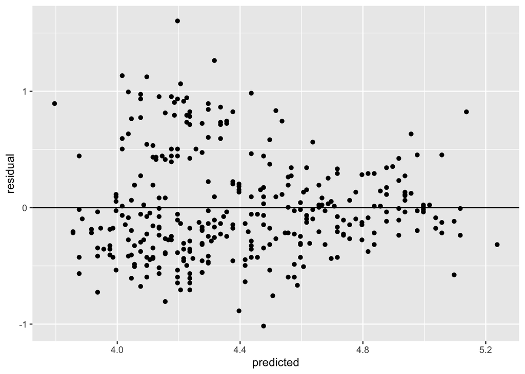

```r
plot_residual_predicted(mod)
```

### Exploratory Data Analysis (EDA)

Let’s do what we should have done first and plot the data.

First, plot the relation between body_mass_kg (x axis) and bill_length_cm (y axis) indicate species by both color and shape and facet by sex. What do you notice?

Take a minute to attempt to create this plot on your own.

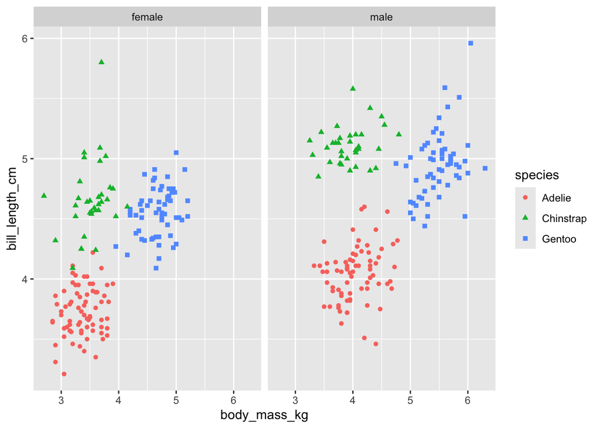

```r
penguins_sc %>%
  ggplot(aes(x=body_mass_kg, y=bill_length_cm, color=species, shape=species)) +
  geom_point() +
  facet_wrap(~sex)
```

Now, let’s use the `scatterPlotMatrix()` function in the `scatterPlotMatrix` package to examine all the relations.

What does `select(-year, -sex, -island)` do? Why might we do this?

```r
scatterPlotMatrix(penguins_sc %>% select(-year, -sex, -island))
```

[interactive chart not shown]

## Fit a new model following our EDA

Let’s predict bill length from flipper length. Use the penguins_sc data.

```r
mod_flip <- lm(bill_length_cm ~ flipper_length_cm, data=penguins_sc)
summary(mod_flip)
```

```
##
## Call:
## lm(formula = bill_length_cm ~ flipper_length_cm, data = penguins_sc)
##
## Residuals:
##      Min       1Q   Median       3Q      Max
## -0.86367 -0.26981 -0.05788  0.20663  1.90953
##
## Coefficients:
##                   Estimate Std. Error t value            Pr(>|t|)
## (Intercept)       -0.72186    0.32717  -2.206               0.028 *
## flipper_length_cm  0.25482    0.01624  15.691 <0.0000000000000002 ***
## ---
## Signif. codes:  0 '***' 0.001 '**' 0.01 '*' 0.05 '.' 0.1 ' ' 1
##
## Residual standard error: 0.4148 on 331 degrees of freedom
## Multiple R-squared:  0.4265, Adjusted R-squared:  0.4248
## F-statistic: 246.2 on 1 and 331 DF,  p-value: < 0.00000000000000022
```

### Inspect its residuals

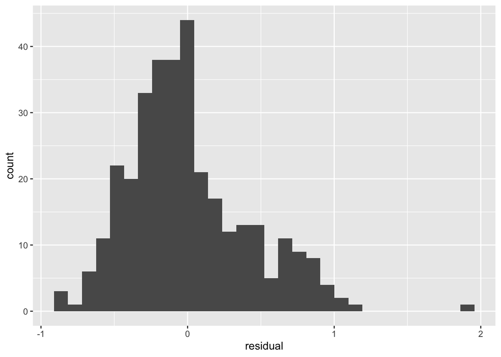

```r
plot_residual_hist(mod_flip)
```

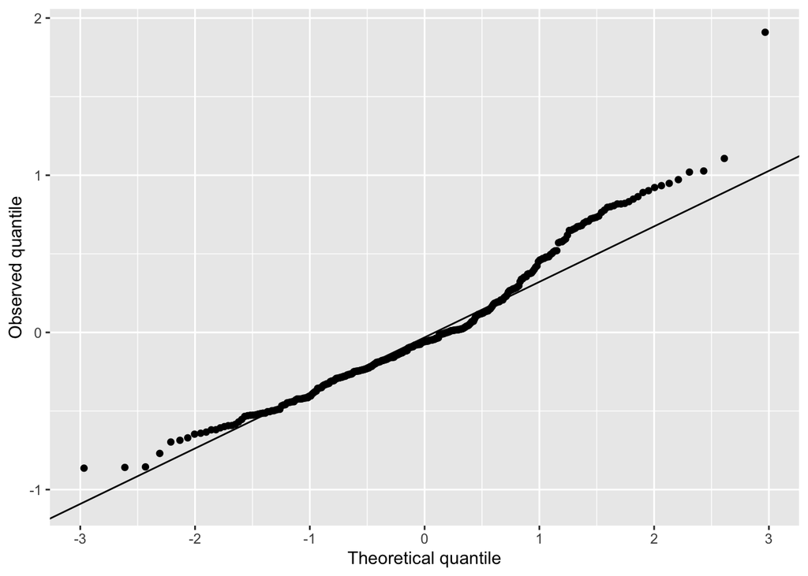

```r
plot_qq(mod_flip)
```

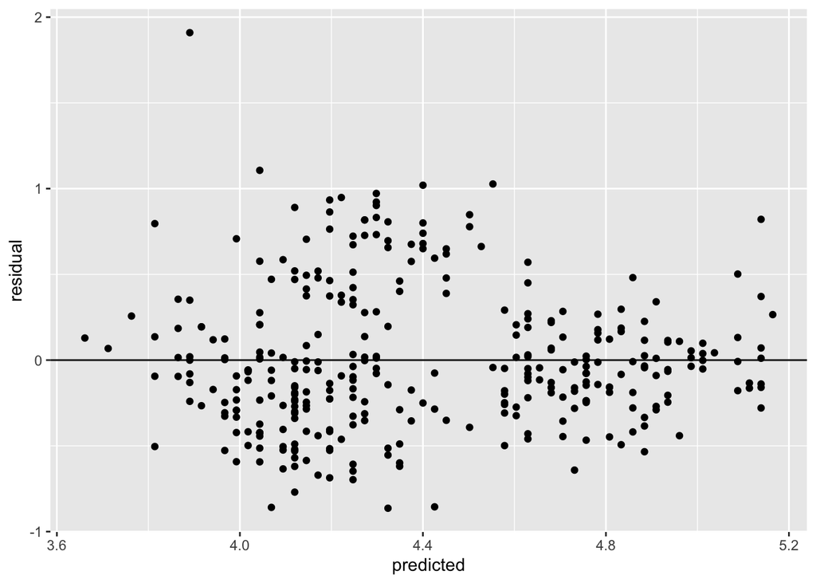

```r
plot_residual_predicted(mod_flip)
```

## Kitchen sink prediction: Let’s try throwing everything in

```r
mod_kit <- lm(bill_length_cm ~ sex + species + flipper_length_cm +
                body_mass_kg + bill_depth_cm, data=penguins_sc)

summary(mod_kit)
```

```
##
## Call:
## lm(formula = bill_length_cm ~ sex + species + flipper_length_cm +
##     body_mass_kg + bill_depth_cm, data = penguins_sc)
##
## Residuals:
##      Min       1Q   Median       3Q      Max
## -0.73939 -0.13424 -0.00421  0.12695  1.14274
##
## Coefficients:
##                   Estimate Std. Error t value             Pr(>|t|)
## (Intercept)        1.50166    0.43742   3.433             0.000674 ***
## sexmale            0.20297    0.03892   5.215        0.00000032680 ***
## speciesChinstrap   0.95655    0.03497  27.351 < 0.0000000000000002 ***
## speciesGentoo      0.64044    0.10304   6.215        0.00000000156 ***
## flipper_length_cm  0.06856    0.02315   2.961             0.003293 **
## body_mass_kg       0.10840    0.04231   2.562             0.010864 *
## bill_depth_cm      0.31298    0.15405   2.032             0.043000 *
## ---
## Signif. codes:  0 '***' 0.001 '**' 0.01 '*' 0.05 '.' 0.1 ' ' 1
##
## Residual standard error: 0.2217 on 326 degrees of freedom
## Multiple R-squared:  0.8386, Adjusted R-squared:  0.8356
## F-statistic: 282.3 on 6 and 326 DF,  p-value: < 0.00000000000000022
```

```r
anova(mod_kit)
```

```
## Analysis of Variance Table
##
## Response: bill_length_cm
##                    Df Sum Sq Mean Sq  F value                Pr(>F)
## sex                 1 11.755  11.755 239.1017 < 0.00000000000000022 ***
## species             2 69.756  34.878 709.4457 < 0.00000000000000022 ***
## flipper_length_cm   1  1.094   1.094  22.2504           0.000003555 ***
## body_mass_kg        1  0.455   0.455   9.2476              0.002549 **
## bill_depth_cm       1  0.203   0.203   4.1276              0.043000 *
## Residuals         326 16.027   0.049
## ---
## Signif. codes:  0 '***' 0.001 '**' 0.01 '*' 0.05 '.' 0.1 ' ' 1
```

```r
# sex * flipper_length_cm

mod_kit_int <- lm(bill_length_cm ~
                sex * (flipper_length_cm + body_mass_kg + bill_depth_cm) +
                species * (flipper_length_cm + body_mass_kg + bill_depth_cm),
              data=penguins_sc)

summary(mod_kit_int)
```

```
##
## Call:
## lm(formula = bill_length_cm ~ sex * (flipper_length_cm + body_mass_kg +
##     bill_depth_cm) + species * (flipper_length_cm + body_mass_kg +
##     bill_depth_cm), data = penguins_sc)
##
## Residuals:
##      Min       1Q   Median       3Q      Max
## -0.63845 -0.13463 -0.00703  0.12965  1.06964
##
## Coefficients:
##                                    Estimate Std. Error t value Pr(>|t|)
## (Intercept)                         2.95245    0.78810   3.746 0.000213 ***
## sexmale                            -0.40503    0.91659  -0.442 0.658872
## flipper_length_cm                   0.01188    0.04007   0.297 0.766970
## body_mass_kg                        0.20630    0.07543   2.735 0.006590 **
## bill_depth_cm                      -0.08036    0.23007  -0.349 0.727104
## speciesChinstrap                   -0.18039    0.99429  -0.181 0.856151
## speciesGentoo                      -1.99579    1.08661  -1.837 0.067189 .
## sexmale:flipper_length_cm           0.04860    0.04346   1.118 0.264380
## sexmale:body_mass_kg               -0.12924    0.07772  -1.663 0.097325 .
## sexmale:bill_depth_cm               0.08721    0.22346   0.390 0.696598
## flipper_length_cm:speciesChinstrap -0.02440    0.06111  -0.399 0.689959
## flipper_length_cm:speciesGentoo     0.08187    0.05763   1.421 0.156409
## body_mass_kg:speciesChinstrap      -0.02650    0.11549  -0.229 0.818695
## body_mass_kg:speciesGentoo         -0.01025    0.09286  -0.110 0.912180
## bill_depth_cm:speciesChinstrap      0.93405    0.36970   2.526 0.012007 *
## bill_depth_cm:speciesGentoo         0.55641    0.39227   1.418 0.157041
## ---
## Signif. codes:  0 '***' 0.001 '**' 0.01 '*' 0.05 '.' 0.1 ' ' 1
##
## Residual standard error: 0.2188 on 317 degrees of freedom
## Multiple R-squared:  0.8471, Adjusted R-squared:  0.8399
## F-statistic: 117.1 on 15 and 317 DF,  p-value: < 0.00000000000000022
```

### Compare with `AIC`

Which is the better model (lower is better)?

AIC differences of:

- 1 or less: models are indistinguishable from each other
- 2-5: some evidence for the better-fitting model
- 5-10: good evidence for the better-fitting model
- 10 or more: strong evidence for the better fitting model

```r
AIC(mod, mod_flip, mod_kit, mod_kit_int)
```

```
##             df       AIC
## mod          3 405.89907
## mod_flip     3 362.88048
## mod_kit      8 -49.26697
## mod_kit_int 17 -49.37345
```

### Visualize coefficients with help from `broom::tidy()`

When a model has many coefficients, sometimes we prefer to visualize them rather than look at a bunch of numbers. `broom::tidy()` can help organize model coefficients into a tibble.

```r
library(broom)

tidy(mod_kit) %>%
  kableExtra::kable(digits=3)
```

| term | estimate | std.error | statistic | p.value |
| --- | --- | --- | --- | --- |
| (Intercept) | 1.502 | 0.437 | 3.433 | 0.001 |
| sexmale | 0.203 | 0.039 | 5.215 | 0.000 |
| speciesChinstrap | 0.957 | 0.035 | 27.351 | 0.000 |
| speciesGentoo | 0.640 | 0.103 | 6.215 | 0.000 |
| flipper_length_cm | 0.069 | 0.023 | 2.961 | 0.003 |
| body_mass_kg | 0.108 | 0.042 | 2.562 | 0.011 |
| bill_depth_cm | 0.313 | 0.154 | 2.032 | 0.043 |

We can also plot the coefficients to compare them.

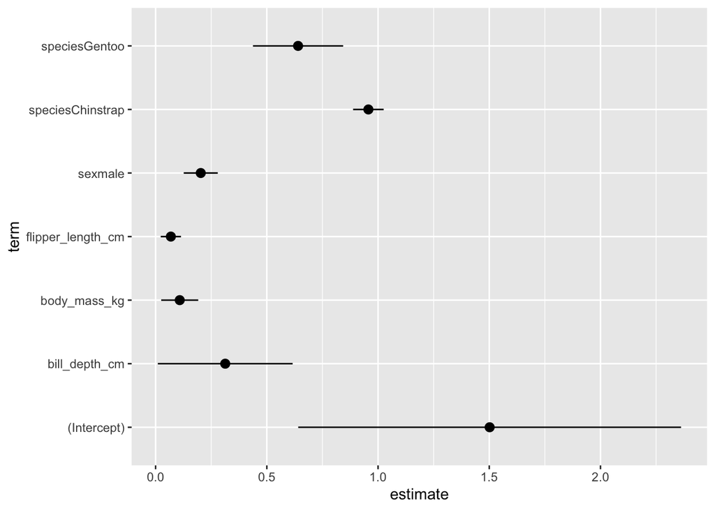

```r
tidy(mod_kit, conf.int = T) %>%
  ggplot(aes(x=term, y=estimate)) +
  geom_point() +
  geom_pointrange(aes(ymin=conf.low, ymax=conf.high)) +
  coord_flip()
```

[^1]: Authored modifications to original code
[^2]: Original author of exercise